# Untitled

Giulia Iannucci

5/2/2021

1. Trust but verify. We trust that the rnorm() will generate random deviates in accordance with the definition of the normal distribution. For example, we learned in this lab, that a normal distribution with mean = 0, and sd =1 , should only produce values larger than 2.5 with a specific small probability, that is P(x>2.5) = 0.006209665. Verify this is approximately the case by randomly sampling 1 million numbers from this distribution, and calculate what proportion of numbers are larger than 2.5. (1 point)

```r
pnorm(2.5 , mean = 0, sd =1, lower.tail = FALSE)
```

```
## [1] 0.006209665
```

```r
my_sample <- rnorm(1000000, mean = 0, sd = 1)

selection <- my_sample[my_sample > 2.5]

length(selection)
```

```
## [1] 6298
```

```r
length(selection)/1000000
```

```
## [1] 0.006298
```

2. If performance on a standardized test was known to follow a normal distribution with mean 100 and standard deviation 10, and 10,000 people took the test, how many people would be expected to achieve a score higher than 3 standard deviations from the mean? (1 point)

```r
pnorm(q = 130, mean = 100, sd = 10, lower.tail = FALSE)
```

```
## [1] 0.001349898
```

```r
10000*pnorm(q = 130, mean = 100, sd = 10, lower.tail = FALSE)
```

```
## [1] 13.49898
```

```r
some_observation <- rnorm(10000, mean = 100, sd = 10)
some_observation[some_observation > 130]
```

```
##  [1] 132.9224 130.9255 133.9507 131.1047 130.1018 132.6695 132.6339 132.2671
##  [9] 132.4320 131.7374 135.4720 132.9145 130.1217 135.2139 133.0534 131.3491
## [17] 133.3613 131.0645
```

```r
length(some_observation[some_observation > 130])/10000
```

```
## [1] 0.0018
```

You randomly sample 25 numbers from a normal distribution with mean = 10 and standard deviation = 20. You obtain a sample mean of 12. You want to know the probability that you could have received a sample mean of 12 or larger.Create a sampling distribution of the mean for this scenario with at least 10,000 sample means (1 point). Then, calculate the proportion of sample means that are 12 or larger (1 point).

```r
mean(rnorm(25, 10, 20))
```

```
## [1] 4.412613
```

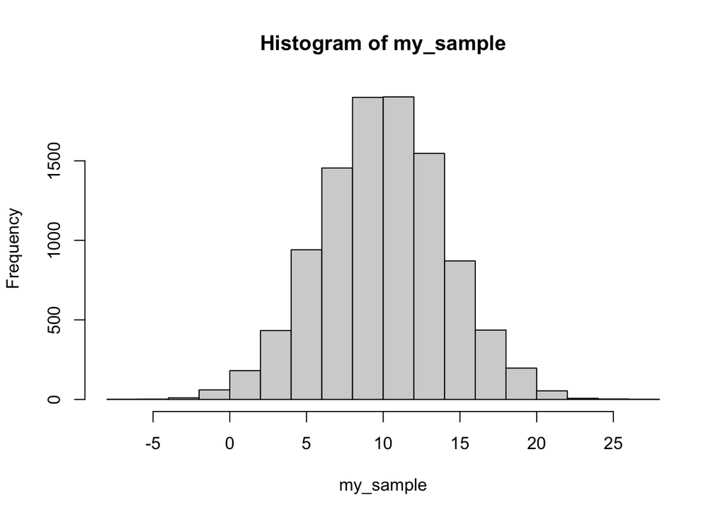

```r
my_sample <- replicate(10000, mean(rnorm(25, 10, 20)))

hist(my_sample)
```

```r
length(my_sample[my_sample >= 12])
```

```
## [1] 3116
```

```r
length(my_sample[my_sample >= 12])/10000
```

```
## [1] 0.3116
```

4. You randomly sample 100 numbers from a normal distribution with mean = 10 and standard deviation = 20. You obtain a sample mean of 12. You want to know the probability that you could have received a sample mean of 12 or larger. Create a sampling distribution of the mean for this scenario with at least 10,000 sample means. Then, calculate the proportion of sample means that are 12 or larger. Is the proportion different from question 3, why? (1 point).

```r
mean(rnorm(100, 10, 20))
```

```
## [1] 13.42902
```

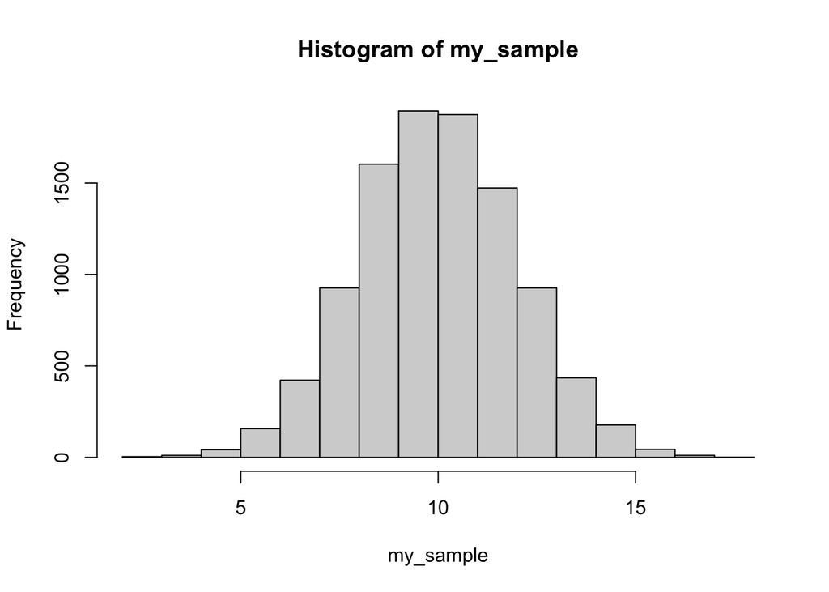

```r
my_sample <- replicate(10000, mean(rnorm(100, 10, 20)))

hist(my_sample)
```

```r
length(my_sample[my_sample >= 12])
```

```
## [1] 1594
```

```r
length(my_sample[my_sample >= 12])/10000
```

```
## [1] 0.1594
```

5. You randomly sample 25 numbers from a normal distribution with mean = 10 and standard deviation = 20. You obtain a sample standard deviation of 15. You want to know the probability that you could have received a sample standard deviation of 15 or less. Create a sampling distribution of standard deviations for this scenario with at least 10,000 sample standard deviations. Then, calculate the proportion of sample standard deviations that are 15 or less. (1 point)

```r
rnorm(25, 10, 20)
```

```
##  [1]  -1.6153576  39.8295577  22.2861220  14.2498955  40.7491360  30.0564192
##  [7]  -2.8349596   9.7278380  25.5254095 -19.6149103  -5.6866852  27.1504188
## [13]  -0.5053993 -18.1815483  22.5746537   4.4422322   4.9385713  12.2655879
## [19]  41.9595449  -8.1307102  -4.8161868  33.7677972 -12.9039091  28.5336159
## [25]   4.3981638
```

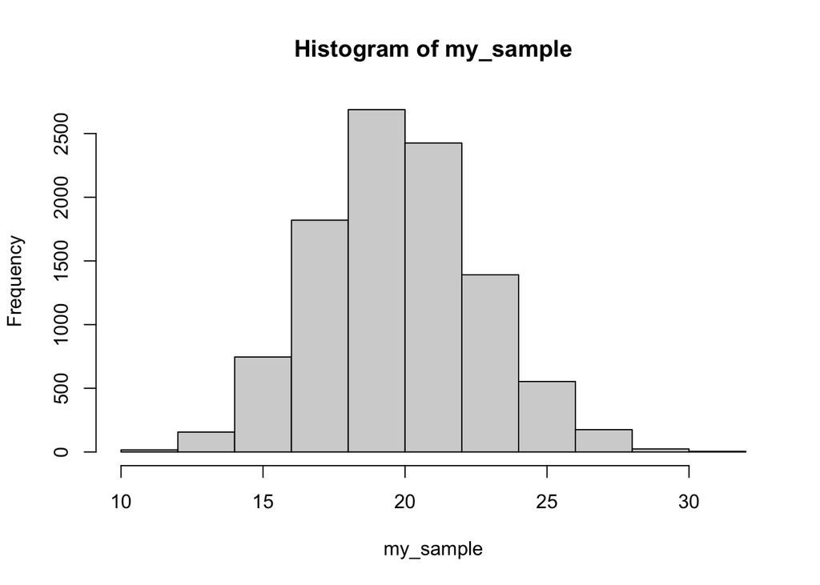

```r
my_sample <- replicate(10000, sd(rnorm(25, 10, 20)))
hist(my_sample)
```

```r
length(my_sample[my_sample <= 15])/10000
```

```
## [1] 0.0442
```